# ISLR chap 3

Hong Anh VU

28 September 2016

First of all we need to load the library:

```r
library(ISLR)
```

## Exo 8

### 8.a

```r
data(Auto); attach(Auto)  # load and attach Auto
fit1 = lm(mpg ~ horsepower)
summary(fit1)
```

```
##
## Call:
## lm(formula = mpg ~ horsepower)
##
## Residuals:
##      Min       1Q   Median       3Q      Max
## -13.5710  -3.2592  -0.3435   2.7630  16.9240
##
## Coefficients:
##              Estimate Std. Error t value Pr(>|t|)
## (Intercept) 39.935861   0.717499   55.66   <2e-16 ***
## horsepower  -0.157845   0.006446  -24.49   <2e-16 ***
## ---
## Signif. codes:  0 '***' 0.001 '**' 0.01 '*' 0.05 '.' 0.1 ' ' 1
##
## Residual standard error: 4.906 on 390 degrees of freedom
## Multiple R-squared:  0.6059, Adjusted R-squared:  0.6049
## F-statistic: 599.7 on 1 and 390 DF,  p-value: < 2.2e-16
```

1. Yes there is a relationship between the predictor and the response, since the p-value is small.
2. We can see how strong it is by R-squared and RSE value.
3. It’s a negative relationship between the predictor and the response because the slope is negative.
4. The result is shown by running code chunk below.

```r
predict(object = fit1, newdata = data.frame(horsepower = c(98)), interval = "confidence")
```

```
##        fit      lwr      upr
## 1 24.46708 23.97308 24.96108
```

```r
predict(object = fit1, newdata = data.frame(horsepower = c(98)), interval = "prediction")
```

```
##        fit     lwr      upr
## 1 24.46708 14.8094 34.12476
```

### 8.b

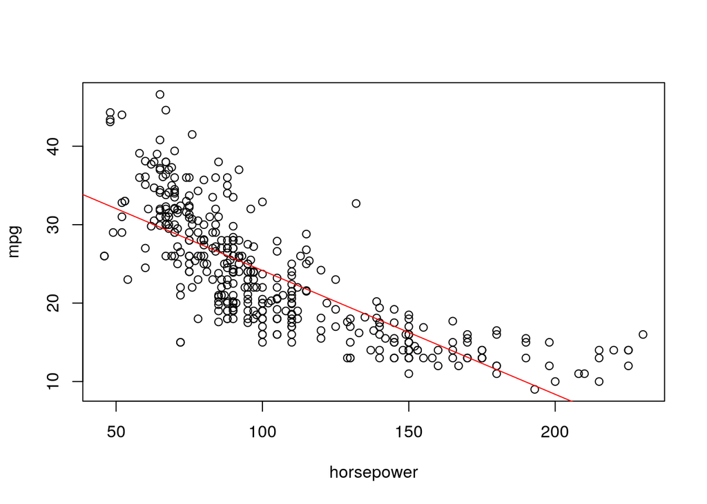

```r
plot(x = horsepower, y = mpg)
abline(reg = fit1, col = "red")  # call abline with regression object fit1
```

### 8.c

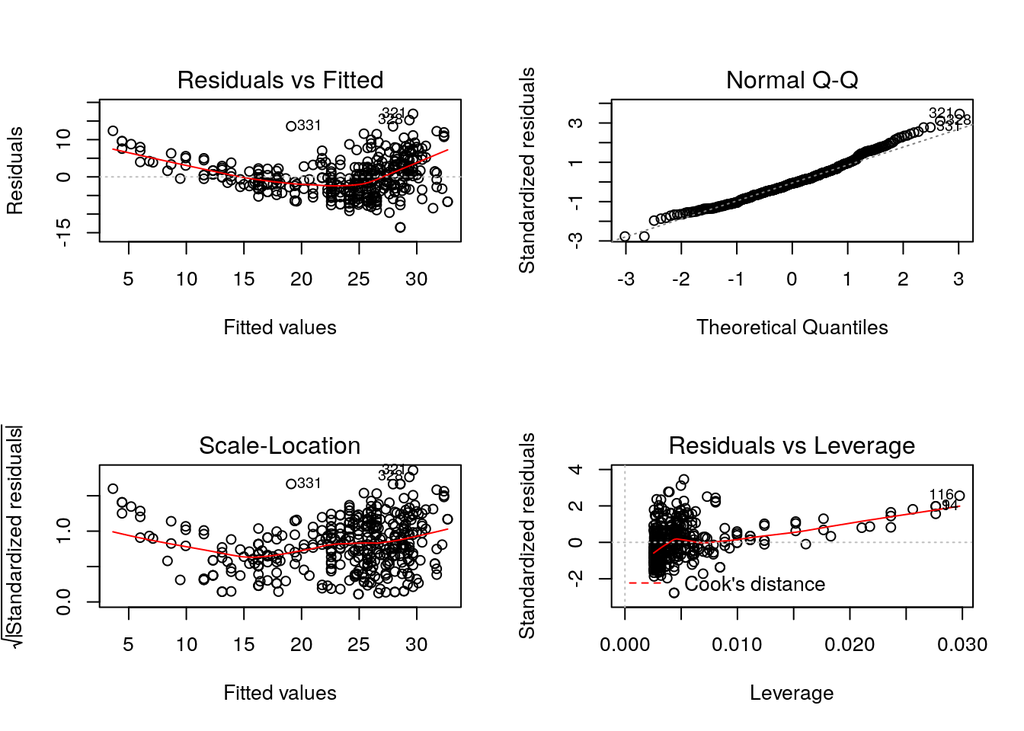

```r
par(mfrow = c(2,2))
plot(fit1)
```

The patterns show us that the true relation is not linear as well as there is some high leverages in data set.

## Exo 9

### 9.a

We can use function **pairs()** to produce scatterplot matrix for every pair of variables in the data set.

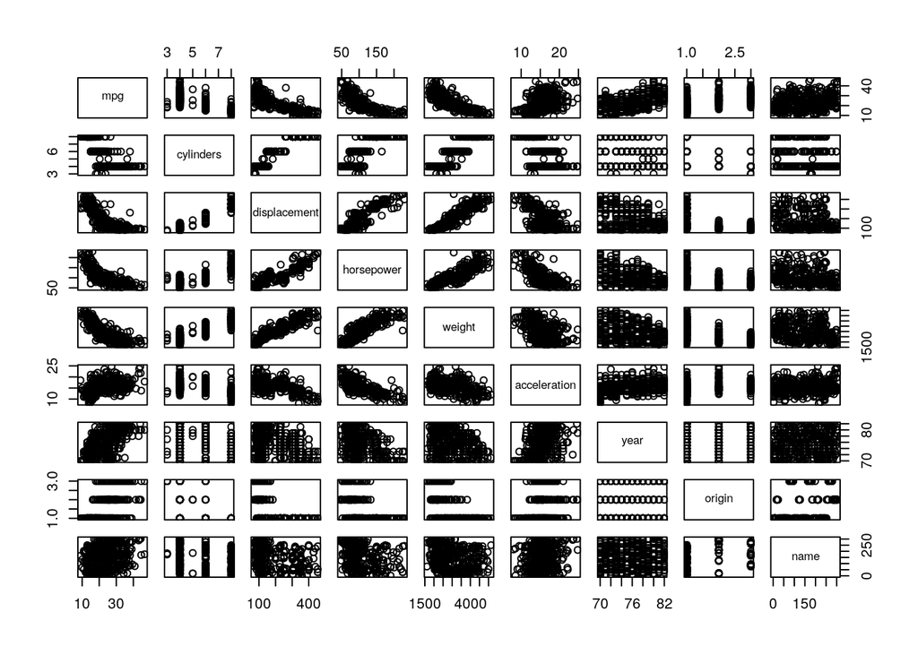

```r
pairs(Auto)
```

### 9.b

To exclude the qualitative variable **name** we can use function **subset()** with parameter **select = -name**.

```r
cor(subset(Auto, select = -name))
```

```
##                     mpg  cylinders displacement horsepower     weight
## mpg           1.0000000 -0.7776175   -0.8051269 -0.7784268 -0.8322442
## cylinders    -0.7776175  1.0000000    0.9508233  0.8429834  0.8975273
## displacement -0.8051269  0.9508233    1.0000000  0.8972570  0.9329944
## horsepower   -0.7784268  0.8429834    0.8972570  1.0000000  0.8645377
## weight       -0.8322442  0.8975273    0.9329944  0.8645377  1.0000000
## acceleration  0.4233285 -0.5046834   -0.5438005 -0.6891955 -0.4168392
## year          0.5805410 -0.3456474   -0.3698552 -0.4163615 -0.3091199
## origin        0.5652088 -0.5689316   -0.6145351 -0.4551715 -0.5850054
##              acceleration       year     origin
## mpg             0.4233285  0.5805410  0.5652088
## cylinders      -0.5046834 -0.3456474 -0.5689316
## displacement   -0.5438005 -0.3698552 -0.6145351
## horsepower     -0.6891955 -0.4163615 -0.4551715
## weight         -0.4168392 -0.3091199 -0.5850054
## acceleration    1.0000000  0.2903161  0.2127458
## year            0.2903161  1.0000000  0.1815277
## origin          0.2127458  0.1815277  1.0000000
```

### 9.c

```r
fit2 = lm(mpg ~ .-name, data = Auto)
summary(fit2)
```

```
##
## Call:
## lm(formula = mpg ~ . - name, data = Auto)
##
## Residuals:
##     Min      1Q  Median      3Q     Max
## -9.5903 -2.1565 -0.1169  1.8690 13.0604
##
## Coefficients:
##                Estimate Std. Error t value Pr(>|t|)
## (Intercept)  -17.218435   4.644294  -3.707  0.00024 ***
## cylinders     -0.493376   0.323282  -1.526  0.12780
## displacement   0.019896   0.007515   2.647  0.00844 **
## horsepower    -0.016951   0.013787  -1.230  0.21963
## weight        -0.006474   0.000652  -9.929  < 2e-16 ***
## acceleration   0.080576   0.098845   0.815  0.41548
## year           0.750773   0.050973  14.729  < 2e-16 ***
## origin         1.426141   0.278136   5.127 4.67e-07 ***
## ---
## Signif. codes:  0 '***' 0.001 '**' 0.01 '*' 0.05 '.' 0.1 ' ' 1
##
## Residual standard error: 3.328 on 384 degrees of freedom
## Multiple R-squared:  0.8215, Adjusted R-squared:  0.8182
## F-statistic: 252.4 on 7 and 384 DF,  p-value: < 2.2e-16
```

1. Yes there is a relationship between the predictors and the response because the F-statistics is big (252.4). Based on that we can reject the null hypothesis (that all slopes equal 0).
2. Predictors appear to have a statisticallyy significant relationship to the response are: **displacement**, **weight**, **year** and **origin**.
3. The coefficient for **year** is 0.751 suggesting that each year the **mpg** increases roughly 0.751.

### 9.d

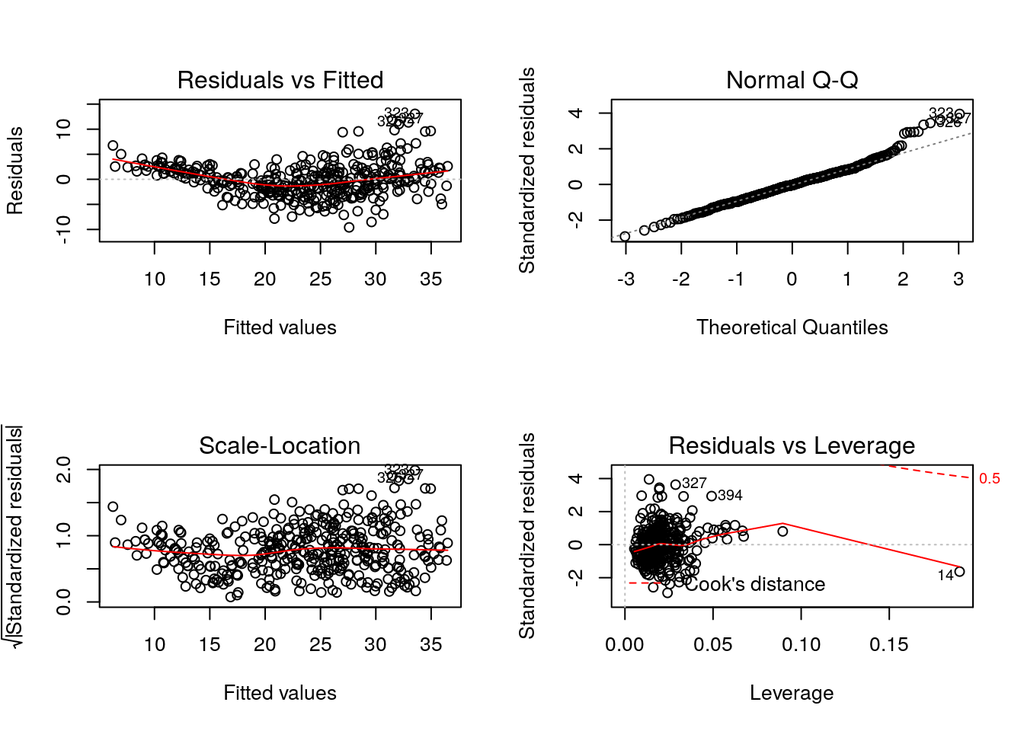

```r
par(mfrow = c(2,2))
plot(fit2)
```

Based on the plot we can see that a non-linearity exists because of discernible curve patterns. There are also some large outliers and some observations with unusually high leverage.

### 9.e

```r
fit3 = lm(mpg ~ displacement * horsepower + weight * horsepower)
summary(fit3)
```

```
##
## Call:
## lm(formula = mpg ~ displacement * horsepower + weight * horsepower)
##
## Residuals:
##      Min       1Q   Median       3Q      Max
## -10.7636  -2.2071  -0.3269   1.9714  16.1650
##
## Coefficients:
##                           Estimate Std. Error t value Pr(>|t|)
## (Intercept)              5.730e+01  2.889e+00  19.835  < 2e-16 ***
## displacement            -5.688e-02  1.568e-02  -3.628 0.000324 ***
## horsepower              -2.204e-01  2.828e-02  -7.794 6.09e-14 ***
## weight                  -4.712e-03  1.836e-03  -2.566 0.010667 *
## displacement:horsepower  3.823e-04  1.112e-04   3.438 0.000650 ***
## horsepower:weight        1.510e-05  1.302e-05   1.160 0.246734
## ---
## Signif. codes:  0 '***' 0.001 '**' 0.01 '*' 0.05 '.' 0.1 ' ' 1
##
## Residual standard error: 3.874 on 386 degrees of freedom
## Multiple R-squared:  0.7568, Adjusted R-squared:  0.7536
## F-statistic: 240.2 on 5 and 386 DF,  p-value: < 2.2e-16
```

As we can see the interaction **displacement:horsepower** appears to be statistically significant.

### 9.f

```r
fit4 = lm(log(mpg) ~ horsepower + I(horsepower^2) + weight)
summary(fit4)
```

```
##
## Call:
## lm(formula = log(mpg) ~ horsepower + I(horsepower^2) + weight)
##
## Residuals:
##      Min       1Q   Median       3Q      Max
## -0.47181 -0.09256  0.00515  0.10195  0.49862
##
## Coefficients:
##                   Estimate Std. Error t value Pr(>|t|)
## (Intercept)      4.358e+00  6.329e-02  68.849  < 2e-16 ***
## horsepower      -8.196e-03  1.350e-03  -6.069 3.07e-09 ***
## I(horsepower^2)  2.012e-05  4.602e-06   4.372 1.58e-05 ***
## weight          -2.191e-04  1.953e-05 -11.217  < 2e-16 ***
## ---
## Signif. codes:  0 '***' 0.001 '**' 0.01 '*' 0.05 '.' 0.1 ' ' 1
##
## Residual standard error: 0.1535 on 388 degrees of freedom
## Multiple R-squared:  0.7979, Adjusted R-squared:  0.7963
## F-statistic: 510.6 on 3 and 388 DF,  p-value: < 2.2e-16
```

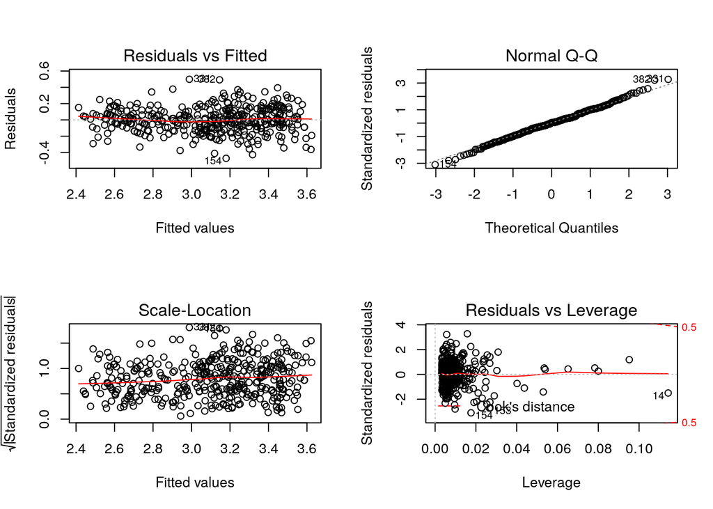

```r
par(mfrow = c(2,2))
plot(fit4)
```

## Exo 11

In this problem we’ll investigate the t-statistic for the null hypothesis $H_0 : \beta = 0$ in simple linear regression without an intercept. Below is the generated data:

```r
set.seed(1)
x = rnorm(100)
y = 2 * x + rnorm(100)
```

### 11.a

Perform a single linear regression **without intercept** on the data set:

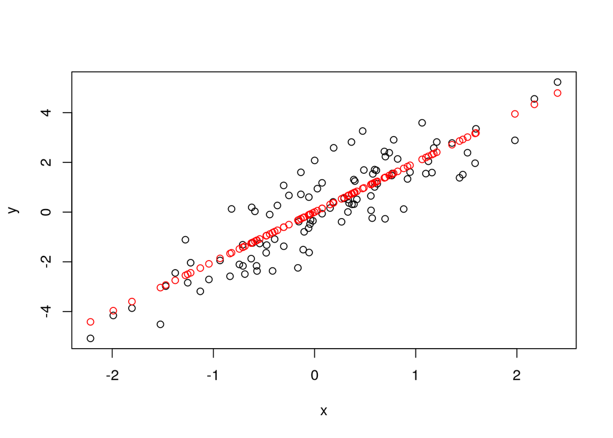

```r
fit1 = lm(y ~ x + 0)
plot(x = x, y = y)
points(x = x, y = fit1$fitted.values, col='red')
```

```r
summary(fit1)
```

```
##
## Call:
## lm(formula = y ~ x + 0)
##
## Residuals:
##     Min      1Q  Median      3Q     Max
## -1.9154 -0.6472 -0.1771  0.5056  2.3109
##
## Coefficients:
##   Estimate Std. Error t value Pr(>|t|)
## x   1.9939     0.1065   18.73   <2e-16 ***
## ---
## Signif. codes:  0 '***' 0.001 '**' 0.01 '*' 0.05 '.' 0.1 ' ' 1
##
## Residual standard error: 0.9586 on 99 degrees of freedom
## Multiple R-squared:  0.7798, Adjusted R-squared:  0.7776
## F-statistic: 350.7 on 1 and 99 DF,  p-value: < 2.2e-16
```

The p-value is small so we can reject the null ($\beta = 0$) where $\beta$ is the slope of linear model between **y and x**:

$$y = \beta x$$

### 11.b

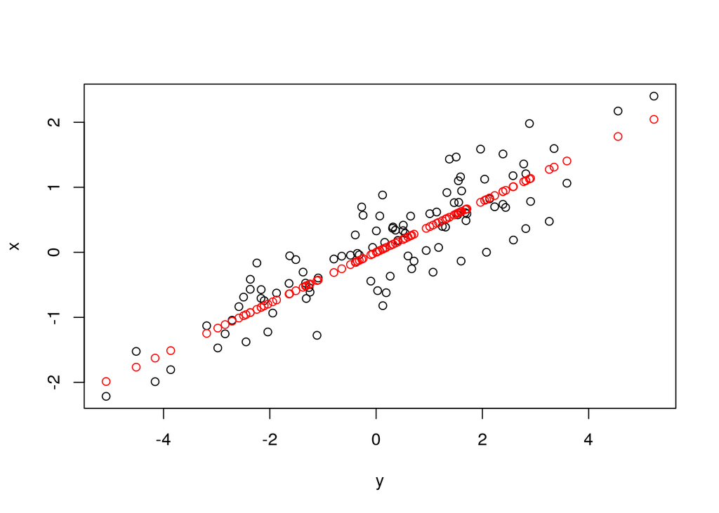

```r
fit2 = lm(x ~ y + 0)
plot(x = y, y = x)
points(x = y, y = fit2$fitted.values, col='red')
```

```r
summary(fit2)
```

```
##
## Call:
## lm(formula = x ~ y + 0)
##
## Residuals:
##     Min      1Q  Median      3Q     Max
## -0.8699 -0.2368  0.1030  0.2858  0.8938
##
## Coefficients:
##   Estimate Std. Error t value Pr(>|t|)
## y  0.39111    0.02089   18.73   <2e-16 ***
## ---
## Signif. codes:  0 '***' 0.001 '**' 0.01 '*' 0.05 '.' 0.1 ' ' 1
##
## Residual standard error: 0.4246 on 99 degrees of freedom
## Multiple R-squared:  0.7798, Adjusted R-squared:  0.7776
## F-statistic: 350.7 on 1 and 99 DF,  p-value: < 2.2e-16
```

The p-value is small so we can reject the null ($\beta' = 0$) where $\beta'$ is the slope of linear model between **x and y**:

$$x = \beta' y$$

### 11.c

The value of $\beta \approx 2$ which is expected. However, the value of $\beta'$ is a little bit supprising when $\beta' \approx 0.391$ which is not 0.5 as expected. This is due to the fact that we simulate the error term ($\varepsilon$) by a standard Normal distribution the same as x ($E \sim N(0,1)$). According to the result from Exo 5, and because random variable $X$ and $E$ independent so $Cov(X,E) = 0$, we have:

$$\hat{\beta} = \frac{\sum x_i y_i}{\sum {x_i}^2} = \frac{(\sum x_i y_i)/n}{(\sum {x_i}^2)/n} \rightarrow 2 + Cov(X,E)/Var(X) = 2$$

Similarly, having $Var(Y) = Var(2*X + E) = 5Var(X)$ we can deduce:

$$\hat{\beta'} = \frac{\sum x_i y_i}{\sum {y_i}^2} = \frac{(\sum x_i y_i)/n}{(\sum {y_i}^2)/n} \rightarrow 2/5 + Cov(X,E)/Var(X) = 2/5 = 0.4$$

Therefore, $\beta' \approx 0.391$ is correct.

### 11.d

The calculation is not short but this is not difficult too. Just put the form of $\hat{\beta}$ in 3.38 to the form of t-statistics and do some calculation with sum, we will obtain the result.

By numerically, we can compute t-statistic by on the result above which is:

```r
n = length(x)
sumxy = sum(x*y)
sumsquaredx = sum(x^2)
sumsquaredy = sum(y^2)
tstats = sqrt(n - 1) * sumxy / sqrt(sumsquaredx * sumsquaredy - sumxy^2)
tstats
```

```
## [1] 18.72593
```

This is nearly the same value for t-statistics from function summary(fit2).

### 11.e

t-statistics formula from 11.d is symetric to x and y. Hence the t-statistics is the same for the regression of **y onto x** as it is for regression of **x onto y**.

### 11.f

```r
fit1 = lm(y ~ x)
fit2 = lm(x ~ y)
summary(fit1)
```

```
##
## Call:
## lm(formula = y ~ x)
##
## Residuals:
##     Min      1Q  Median      3Q     Max
## -1.8768 -0.6138 -0.1395  0.5394  2.3462
##
## Coefficients:
##             Estimate Std. Error t value Pr(>|t|)
## (Intercept) -0.03769    0.09699  -0.389    0.698
## x            1.99894    0.10773  18.556   <2e-16 ***
## ---
## Signif. codes:  0 '***' 0.001 '**' 0.01 '*' 0.05 '.' 0.1 ' ' 1
##
## Residual standard error: 0.9628 on 98 degrees of freedom
## Multiple R-squared:  0.7784, Adjusted R-squared:  0.7762
## F-statistic: 344.3 on 1 and 98 DF,  p-value: < 2.2e-16
```

```r
summary(fit2)
```

```
##
## Call:
## lm(formula = x ~ y)
##
## Residuals:
##      Min       1Q   Median       3Q      Max
## -0.90848 -0.28101  0.06274  0.24570  0.85736
##
## Coefficients:
##             Estimate Std. Error t value Pr(>|t|)
## (Intercept)  0.03880    0.04266    0.91    0.365
## y            0.38942    0.02099   18.56   <2e-16 ***
## ---
## Signif. codes:  0 '***' 0.001 '**' 0.01 '*' 0.05 '.' 0.1 ' ' 1
##
## Residual standard error: 0.4249 on 98 degrees of freedom
## Multiple R-squared:  0.7784, Adjusted R-squared:  0.7762
## F-statistic: 344.3 on 1 and 98 DF,  p-value: < 2.2e-16
```

We can see that the t-value for slope in 2 regressions roughly equals 18.56

## Exo 13

### 13.a and 13.b

Create a vector **x**, containing 100 observations drawn from a N(0,1) distribution and a vector **eps** drawn from a N(0,0.25):

```r
set.seed(1)
x = rnorm(100, mean = 0, sd = 1)
eps = rnorm(100, mean = 0, sd = 0.25)
```

### 13.c

Using **x** and **eps** generate a vector **y** according to model:

$$\label{testtag}
Y = -1 + 0.5X + \epsilon$$

```r
y = -1 + 0.5 * x + eps
```

The equation $\ref{testtag}$ shows that vector **y** has the same length (length = 100) as vector **x**. From the model, we have intercept $\beta_0 = -1$ and slope $\beta_1 = 0.5$.

### 13.d

We expect to see a linear relationship between **x** and **y**. The range of **x** is expected to lie mostly in [-2, 2].

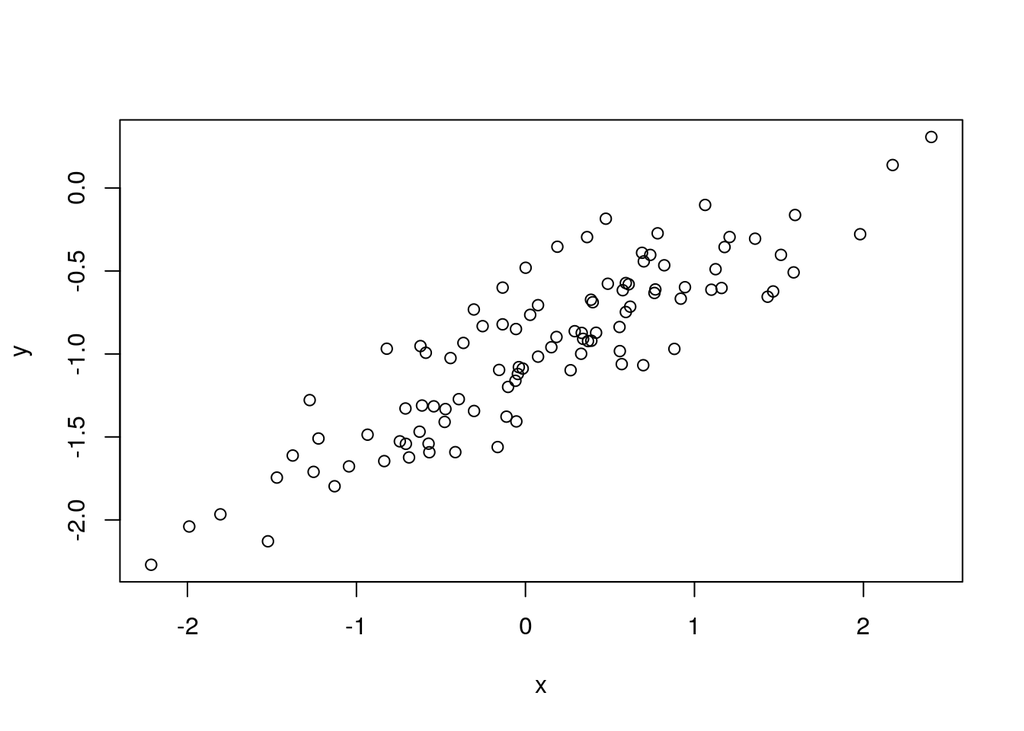

```r
plot(x, y)
```

### 13.e

```r
fit = lm(y ~ x)
summary(fit)
```

```
##
## Call:
## lm(formula = y ~ x)
##
## Residuals:
##      Min       1Q   Median       3Q      Max
## -0.46921 -0.15344 -0.03487  0.13485  0.58654
##
## Coefficients:
##             Estimate Std. Error t value Pr(>|t|)
## (Intercept) -1.00942    0.02425  -41.63   <2e-16 ***
## x            0.49973    0.02693   18.56   <2e-16 ***
## ---
## Signif. codes:  0 '***' 0.001 '**' 0.01 '*' 0.05 '.' 0.1 ' ' 1
##
## Residual standard error: 0.2407 on 98 degrees of freedom
## Multiple R-squared:  0.7784, Adjusted R-squared:  0.7762
## F-statistic: 344.3 on 1 and 98 DF,  p-value: < 2.2e-16
```

We can see that $\hat{\beta_0} \approx -1.01$ and $\hat{\beta_1} \approx 0.50$ which are really close to $\beta_0 = -1$ and $\beta_1 = 0.5$

### 13.f

Display the least squares line (in red) on the scatterplot and also draw the population regression line (in green) on the plot:

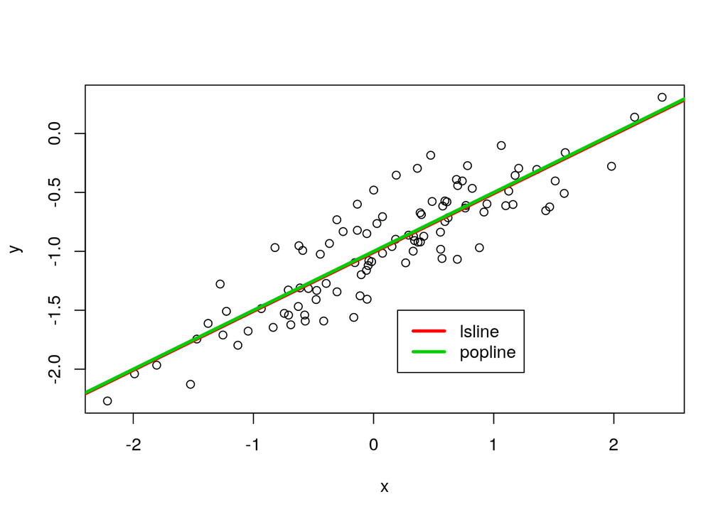

```r
plot(x, y)
abline(fit, col = 2, lwd = 3)
abline(a = -1, b = 0.5, col = 3, lwd = 3)
legend(x = 0.2, y = -1.5, legend = c("lsline", "popline"), col = 2:3, lwd = 3)
```

### 13.g

Fit a model that predicts y using x and x^2

```r
fit2 = lm(y ~ x + I(x^2))
summary(fit2)
```

```
##
## Call:
## lm(formula = y ~ x + I(x^2))
##
## Residuals:
##     Min      1Q  Median      3Q     Max
## -0.4913 -0.1563 -0.0322  0.1451  0.5675
##
## Coefficients:
##             Estimate Std. Error t value Pr(>|t|)
## (Intercept) -0.98582    0.02941 -33.516   <2e-16 ***
## x            0.50429    0.02700  18.680   <2e-16 ***
## I(x^2)      -0.02973    0.02119  -1.403    0.164
## ---
## Signif. codes:  0 '***' 0.001 '**' 0.01 '*' 0.05 '.' 0.1 ' ' 1
##
## Residual standard error: 0.2395 on 97 degrees of freedom
## Multiple R-squared:  0.7828, Adjusted R-squared:  0.7784
## F-statistic: 174.8 on 2 and 97 DF,  p-value: < 2.2e-16
```

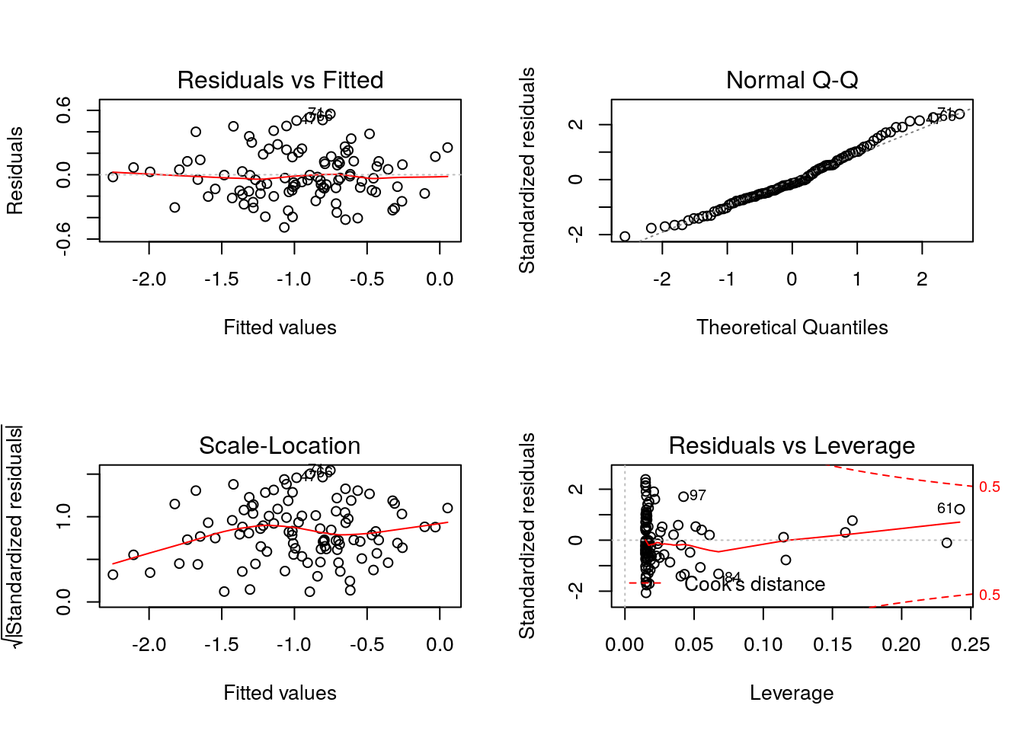

```r
par(mfrow = c(2,2))
plot(fit2)
```

We can see that the quadratic term is not statistically significant since its p-value is big (16.4%). So it does not improve the model.

### 13.h, 13.i and 13.j

Of course the model with less noise will be closer to the true model. The less noise in the data generated, the smaller the confidence interval.

## Exo 14

### 14.a

```r
set.seed(1)
x1 = runif(100)
x2 = 0.5*x1 + rnorm(100)/10
y = 2 + 2*x1 + 0.3*x2 + rnorm(100)
```

The form of this linear model is:
$$Y = 2 + 2 X_1 + 0.3 X_2 + \epsilon$$

```r
cor(x1, x2)
```

```
## [1] 0.8351212
```

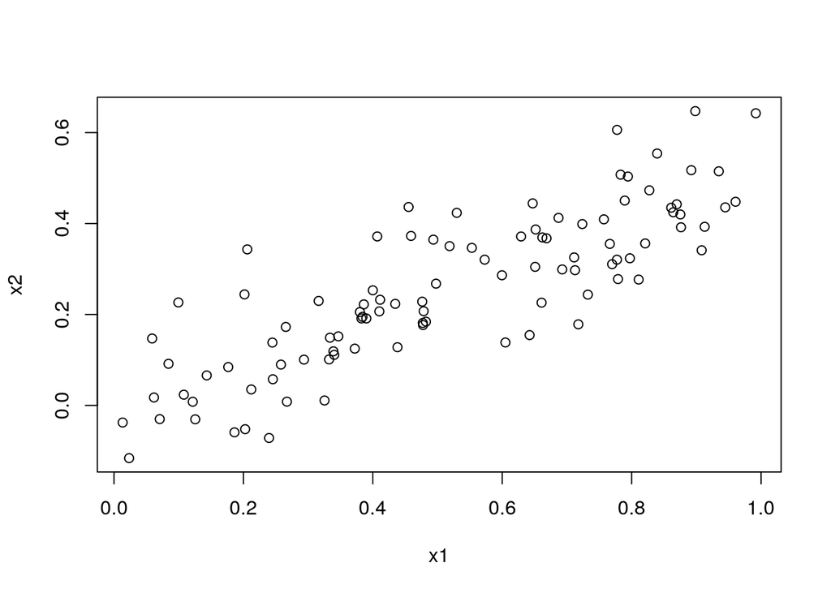

```r
plot(x1, x2)
```

We can see that their correlation is quite high and also in the plot we see a linear relationship between x1 and x2.

### 14.c

```r
fit1 = lm(y ~ x1 + x2)
summary(fit1)
```

```
##
## Call:
## lm(formula = y ~ x1 + x2)
##
## Residuals:
##     Min      1Q  Median      3Q     Max
## -2.8311 -0.7273 -0.0537  0.6338  2.3359
##
## Coefficients:
##             Estimate Std. Error t value Pr(>|t|)
## (Intercept)   2.1305     0.2319   9.188 7.61e-15 ***
## x1            1.4396     0.7212   1.996   0.0487 *
## x2            1.0097     1.1337   0.891   0.3754
## ---
## Signif. codes:  0 '***' 0.001 '**' 0.01 '*' 0.05 '.' 0.1 ' ' 1
##
## Residual standard error: 1.056 on 97 degrees of freedom
## Multiple R-squared:  0.2088, Adjusted R-squared:  0.1925
## F-statistic:  12.8 on 2 and 97 DF,  p-value: 1.164e-05
```

From output we have $\hat{\beta}_0 \approx 2.131$, $\hat{\beta}_1 \approx 1.440$ and $\hat{\beta}_2 \approx 1.010$. We see that only $\hat{\beta}_0$ and $\hat{\beta}_1$ are statistically significant since their p-values are small enough to reject the null hypothesis. In addition, the estimated values $\hat{\beta}_0$ is near, $\hat{\beta}_1$ is a bit far and $\hat{\beta}_2$ is quite far to the true parameter.

### 14.d and 14.e

Fit y and x1:

```r
fit2 = lm(y ~ x1)
summary(fit2)
```

```
##
## Call:
## lm(formula = y ~ x1)
##
## Residuals:
##      Min       1Q   Median       3Q      Max
## -2.89495 -0.66874 -0.07785  0.59221  2.45560
##
## Coefficients:
##             Estimate Std. Error t value Pr(>|t|)
## (Intercept)   2.1124     0.2307   9.155 8.27e-15 ***
## x1            1.9759     0.3963   4.986 2.66e-06 ***
## ---
## Signif. codes:  0 '***' 0.001 '**' 0.01 '*' 0.05 '.' 0.1 ' ' 1
##
## Residual standard error: 1.055 on 98 degrees of freedom
## Multiple R-squared:  0.2024, Adjusted R-squared:  0.1942
## F-statistic: 24.86 on 1 and 98 DF,  p-value: 2.661e-06
```

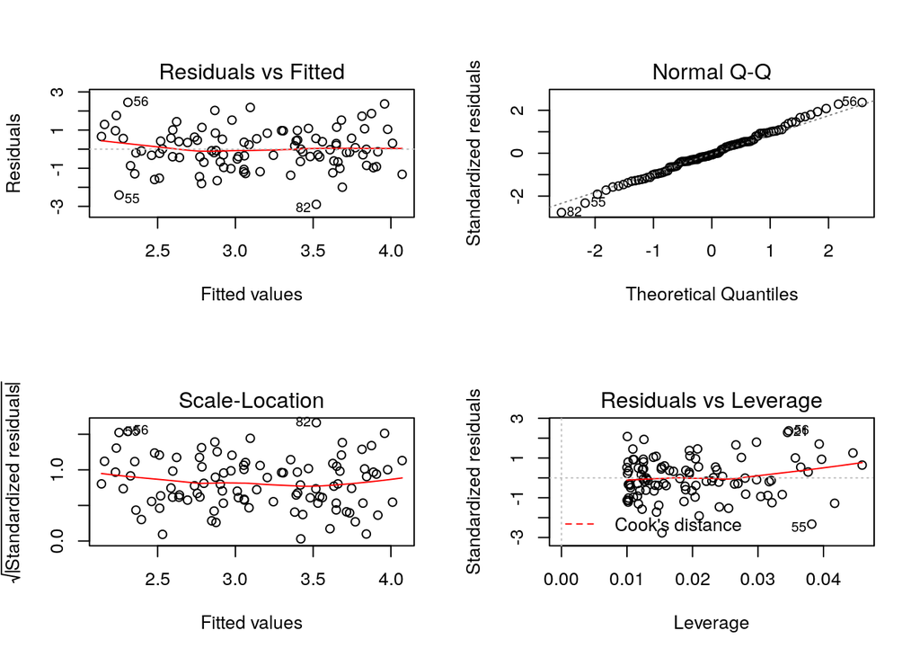

```r
par(mfrow = c(2,2))
plot(fit2)
```

Fit y and x2:

```r
fit3 = lm(y ~ x2)
summary(fit3)
```

```
##
## Call:
## lm(formula = y ~ x2)
##
## Residuals:
##      Min       1Q   Median       3Q      Max
## -2.62687 -0.75156 -0.03598  0.72383  2.44890
##
## Coefficients:
##             Estimate Std. Error t value Pr(>|t|)
## (Intercept)   2.3899     0.1949   12.26  < 2e-16 ***
## x2            2.8996     0.6330    4.58 1.37e-05 ***
## ---
## Signif. codes:  0 '***' 0.001 '**' 0.01 '*' 0.05 '.' 0.1 ' ' 1
##
## Residual standard error: 1.072 on 98 degrees of freedom
## Multiple R-squared:  0.1763, Adjusted R-squared:  0.1679
## F-statistic: 20.98 on 1 and 98 DF,  p-value: 1.366e-05
```

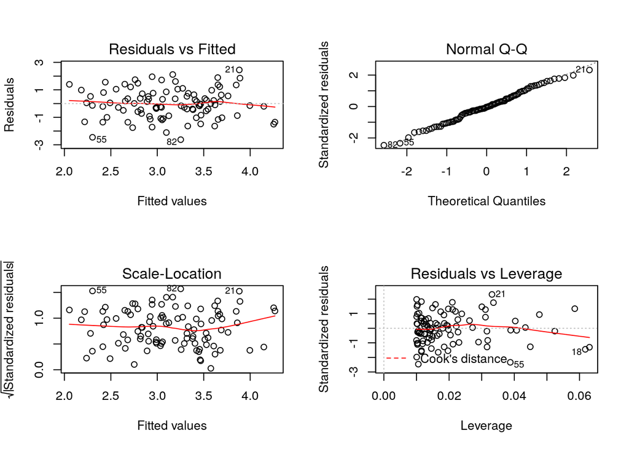

```r
par(mfrow = c(2,2))
plot(fit3)
```

We reject null hypothesis in both case because their p-value is small.

### 14.f

No results in 14.c and 14.e do not contradict each other. This is the problem of collinearity between x1 and x2. When combine together like in 14.c, the presence of x2 is masked by the collinearity of x1 and x2.

### 14.g

Add a data case to the data set then fit the linear model as below:

```r
 x1 = c(x1, 0.1)
x2 = c(x2, 0.8)
y = c(y, 6)

fit4 = lm(y ~ x1 + x2)
summary(fit4)
```

```
##
## Call:
## lm(formula = y ~ x1 + x2)
##
## Residuals:
##      Min       1Q   Median       3Q      Max
## -2.73348 -0.69318 -0.05263  0.66385  2.30619
##
## Coefficients:
##             Estimate Std. Error t value Pr(>|t|)
## (Intercept)   2.2267     0.2314   9.624 7.91e-16 ***
## x1            0.5394     0.5922   0.911  0.36458
## x2            2.5146     0.8977   2.801  0.00614 **
## ---
## Signif. codes:  0 '***' 0.001 '**' 0.01 '*' 0.05 '.' 0.1 ' ' 1
##
## Residual standard error: 1.075 on 98 degrees of freedom
## Multiple R-squared:  0.2188, Adjusted R-squared:  0.2029
## F-statistic: 13.72 on 2 and 98 DF,  p-value: 5.564e-06
```

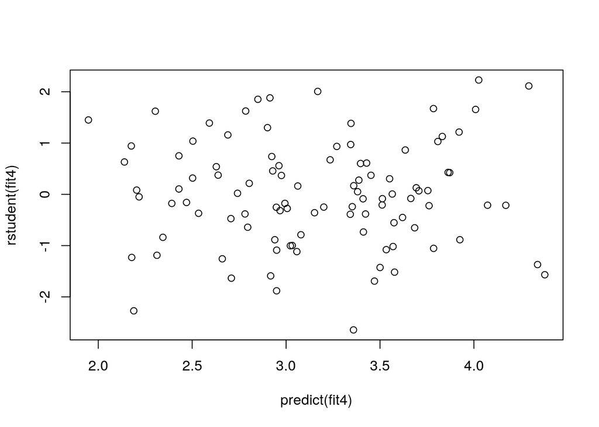

```r
par(mfrow = c(1, 1))
plot(predict(fit4), rstudent(fit4))
```

First, we see that now $\beta_1$ is statistically insignificant while $\beta_2$ become statistically significant. This is expected because if there is a collinearity between x1 and x2, a small change in data set can lead to a big change in the whole regression result.

Second, the plot of studentized residual does not show any significant outlier. Hence we can say that this is not a problem of outlier.

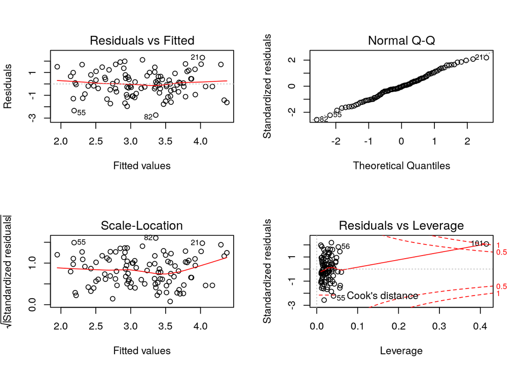

```r
par(mfrow = c(2, 2))
plot(fit4)
```

Yes this is a problem of high leverage point for the new data case (idx 101) since its Cook’s distance is very high. We should exclude this case from the data set.